# Lower the barrier. Keep the bar.

Week 14 · Chapters 4 and 5 · Intelligence, individual differences and exceptionalities

Study · Week 14

Read Chapters 4 and 5 of the textbook (Eggen & Kauchak, 2025) before you read this brief. Chapter 4 covers culture, language and income, and Chapter 5 covers intelligence, ability grouping and learners with exceptionalities. The brief examines both chapters with one question: when a student struggles, do you change the barrier or the bar?

About 45 minutes: reading, two places you stop and write, and eight quick checks.

## The district file

This week you read a district file with seventeen students. Two of them were evaluated because a parent asked, and both parents knew exactly what to ask for. Another referral ended because nobody followed up on a consent form. The district now uses a screening tool that learns from that record.

Keep the file open while you read, because every idea in this brief comes back to it.

One question runs through the week: **When a student struggles, what do you change?** You can change the *barrier*, which is whatever stands between the student and the learning, or you can change the *bar*, which is what the student is expected to learn. Most new teachers change the bar because it feels kind, although it is usually the wrong decision.

## What intelligence is

Chapter 5 defines intelligence as the ability to acquire knowledge, to think and reason in the abstract, and to solve problems. For a century, psychologists have debated whether that is one ability or many.

One general ability Charles Spearman (1904) noticed that people who do well on one kind of mental test tend to do well on the others. He called the shared part *g*, or general intelligence, and most modern IQ tests report a total score built on that idea.

Broad and narrow abilities The Cattell–Horn–Carroll model (McGrew, 2009) keeps *g* at the top and adds broad abilities under it: reasoning with new problems, stored knowledge, processing speed, working memory, visual and auditory processing. Most school psychologists read test results through this model.

Multiple intelligences Howard Gardner (1983) proposed separate intelligences: linguistic, logical-mathematical, spatial, musical, bodily-kinesthetic, interpersonal, intrapersonal and naturalist. The theory is popular with teachers, but its research support is weak because the intelligences overlap more than the theory predicts. It remains useful as a reminder that school rewards two or three of these abilities and ignores the rest.

Successful intelligence Robert Sternberg (1985) describes three abilities: analytical (solve the problem on the page), creative (deal with a new problem) and practical (adapt to the world you live in). Because most tests measure only the analytical ability, they can miss a student who is low on the first and high on the other two.

Adaptive intelligence Sternberg later asked what intelligence is for (Sternberg, 2021). He describes a paradox: IQ scores rose for a century, and yet the world’s big problems, from climate change to pandemics, did not shrink. Tests reward people who solve someone else’s problem fast. **Adaptive intelligence** is using your abilities to solve real problems for the common good, over the long run as well as today, so it counts what a student does with the score.

**What IQ predicts.** IQ is one of the strongest single predictors in psychology. It predicts school grades well (Deary et al., 2007), and it predicts how long people stay in school and, more weakly, success at work.

**What changes IQ.** Intelligence grows with schooling. A review of natural experiments found that each extra year of education raises IQ by one to five points (Ritchie & Tucker-Drob, 2018). Average scores also rose about three points per decade across the 20th century, a pattern called the **Flynn effect** (Flynn, 1987). Because genes do not change that fast, the explanation lies in schools, nutrition and the mental demands of daily life.

**Some scores are now falling.** In Norway, scores of young men born after about 1975 started to drop. Because the drop shows up between brothers in the same family, genes and family background cannot explain it, and something in the environment must have changed (Bratsberg & Rogeberg, 2018). A large U.S. online sample found declines from 2006 to 2018 in verbal reasoning and matrix problems, with a gain in spatial reasoning (Dworak et al., 2023). Nobody knows the cause yet, although changes in schooling, reading habits, screens and the tests themselves are all possible. Rising and falling scores teach the same lesson: the environment moves the score, and the environment now includes the tools students think with. Whether offloading thinking to tools is part of the cause is still an open question, and it is a fair one to ask.

**A test score describes what a student can do today, under these conditions.** It does not set a ceiling, and the environment you build influences it.

True or false?

IQ is fixed at birth, so a teacher can use it to predict what a student will ever be able to learn.

Not quite Schooling raises IQ, and whole countries gained about three points a decade in the 20th century. A score is a snapshot of today, under today’s conditions.

Right IQ predicts school performance, and it also changes. Each year of schooling raises it a little, and the Flynn effect shows how much the environment matters.

### Ability grouping and learning styles

Chapter 5 describes **ability grouping**, which places students with similar scores together. Between-class grouping (tracking) has a cost, because students in low tracks get less challenging work, less experienced teachers and lower expectations, and few of them ever move up. Flexible grouping within a class works better: teachers form groups for one skill, keep them for a few weeks, and then mix the students again.

Chapter 5 also examines **learning styles**, the claim that a “visual learner” learns better from pictures and an “auditory learner” from talk. Students like the idea, but when researchers test it properly, matching teaching to a preferred style does not improve learning (Pashler et al., 2008). The content decides the format: maps are visual for every learner, and pronunciation is auditory for every learner.

Check yourself

A colleague says, *“Darius is a kinesthetic learner, so I let him skip the readings and do the hands-on station instead.”* What does Chapter 5 say?

The evidence says no Studies that test style matching properly find no benefit (Pashler et al., 2008). Darius just lost the reading.

Yes The plan has two problems. The style claim fails when tested, and the “fix” removes a task his peers still do, which lowers the bar for him.

No test fixes it A preference you can measure still doesn’t predict who learns better from which format.

No An accommodation comes from a documented need in an IEP or 504 plan. A style label creates no legal right, and this plan removes no barrier.

## Talent is developed

Intelligence is a starting point. **Talent** is what a person builds with it over years, in a domain, with teaching, practice and opportunity. Subotnik et al. (2011) describe talent development in four claims:

1. Abilities matter, and they can grow.
2. Each domain has its own path. Math talent shows early, whereas talent in history or psychology often shows late.
3. Opportunity has to be offered, and taken.
4. Psychosocial skills decide a lot, including persistence, coping with criticism, and belief in your own growth.

Schools are not the only institutions that try to find and develop talent. Sports teams scout athletes, and companies pick and train future leaders. Jonathan Wai and I mapped 80 years of talent identification research across these fields (Parra-Martinez & Wai, 2023). Every field has to decide who has potential, where to invest, and when to check again, yet the fields rarely read each other’s work.

Sport teaches a lesson that schools often forget. A good scout does not test a child once, at age eight, and then stop looking. Because scouts watch players again every season, a late bloomer gets another look.

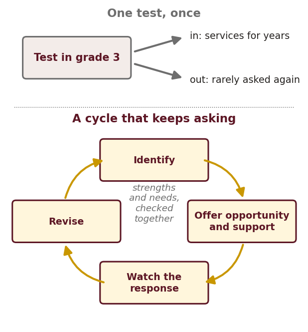

Two models of talent identification. A gate tests once in grade 3 and sorts students for years. A cycle keeps asking.

In a paper that Ophélie Desmet and I just published, we call this cycle **talent management** (Parra-Martinez & Desmet, 2026). Schools identify students, offer opportunity and support, watch how each student responds, and then revise the plan. The cycle never stops at one score, and it checks strengths and needs together. It also uses more than achievement data, because motivation, well-being and the student’s own account count too.

Your district file describes a gate. Tanya and D’Andre went through it because a parent pushed, Matthew stopped at a consent form, and nobody looked again.

**An asset-based teacher starts from what a student can do,** then removes what blocks the rest. A deficit-based teacher starts from the gap and builds the whole plan around it.

## Intelligence when students use AI

Every student you teach will have AI in their pocket. AI changes what intelligence looks like in your classroom, and it also changes what you can learn from a student’s work.

In the same paper, Desmet and I name three things that can happen when a learner works with AI (Parra-Martinez & Desmet, 2026).

Offloading Using a tool to reduce the mental work of a task (Risko & Gilbert, 2016), as a calculator does with arithmetic. Offloading is a choice about where the thinking happens. An expert who offloads a routine step saves effort for the hard part, whereas a learner who offloads the step they are supposed to be learning loses the practice.

Surrender Accepting the tool’s output without checking it (Shaw & Nave, 2026). The student asks AI to do the work and then copies the result. The product looks fine and the student’s confidence goes up, although the understanding is missing.

Augmentation The learner’s judgment and the tool’s capability together produce work that neither could produce alone, and the learner grows. This learner can explain the work, catch the tool’s errors, and do better next time.

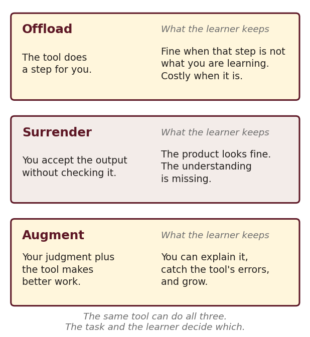

Offload, surrender and augment. The same tool can lead to all three.

The strongest evidence so far comes from a randomized trial in Turkish high schools (Bastani et al., 2025). Students who practiced math with unrestricted GPT-4 did 48% better on practice problems, but on the exam, without the tool, they did 17% worse than students who never had it. A version that only gave teacher-designed hints improved practice without that loss.

Both versions used the same AI model, so the design decided whether students offloaded the learning or kept it.

**What this means for your subject.** AI recalls facts on demand, but it cannot decide what matters for your student, check its own answer, or answer for the consequences. Those tasks require thinking skills: framing a problem, weighing evidence, catching an error and defending a choice. Sternberg’s adaptive intelligence adds one more, which is deciding whether the work is worth doing, and for whom. These skills are worth more every year, whereas recall for its own sake is worth less. Remember one warning from Week 7, that judgment depends on knowledge. A student who knows nothing about the Civil War cannot catch an AI’s error about it, so teach the knowledge, and teach students to use it.

True or false?

A student can turn in excellent work made with AI and still have learned less than a classmate who worked without it.

Right Bastani et al. found better practice scores and worse exam scores. Assisted work and independent capability are two different things, so check them separately.

Not quite In the Bastani trial, students with unrestricted AI did better on practice and worse on the exam without it. The product hid the missing learning.

## When teachers read difference as a ceiling

Chapter 4 examines the differences students bring to school, including culture, language, income and gender. A teacher can read each one as an asset or as a ceiling, and teachers often pick the ceiling without noticing.

**Language.** In Week 3 you learned about BICS and CALP: everyday language develops in a year or two, whereas academic language takes five to seven. A student who is still learning academic English may reason at a high level in another language. English learner status describes a service the school provides, and it says nothing about the student’s ability.

**Culture.** Students bring ways of talking, working and showing respect that school may or may not reward. Culturally responsive teaching (Week 12) builds on what students bring.

**Income.** Chapter 4 shows that family income predicts achievement. We should interpret this relation as a difference in **opportunity**, because children from low-income families get fewer books at home, fewer summer programs, and schools with fewer experienced teachers. Ziegler and Baker (2013) call these resources *educational capital* and *learning capital*. They are unequally distributed, and they influence what a test later reports as ability.

**How strong is the relation?** Family income and parents’ schooling, together called **socioeconomic status (SES)**, are among the strongest predictors of achievement that schools record. A review of 58 studies found an average correlation of about .3 for individual students, and a stronger one when whole schools are compared (Sirin, 2005). U.S. reports usually split scores by race, ethnicity and gender. Those groups matter and the comparisons catch real gaps, but they leave out what a family can provide, and when. Three studies show what socioeconomic status adds.

**Study 1: income and the brain.** Kimberly Noble’s team scanned the brains of 1,099 children and young people, ages 3 to 20 (Noble et al., 2015). Higher family income was associated with more surface area on the cortex, most in regions for language, reading, executive function and spatial skills, and the association held after the team accounted for genetic ancestry. The relation is a curve. Near the bottom, a few thousand dollars is associated with a large difference, whereas near the top the same amount is associated with almost none. Income matters most where there is least of it.

The study has two limits. It found a correlation from one scan per child, so it shows a link and cannot show that money builds brains. In addition, the dots in the figure show that at every income level children spread across almost the whole range, which means that the curve describes groups and cannot tell you about the child in front of you. Brains also change with experience, and for that reason the second study matters.

**Study 2: opportunities add up.** Eric Dearing’s team followed 814 children for 26 years, from birth, and counted opportunities in five places: home, childcare, school, afterschool and the neighborhood (Dearing et al., 2024). Children from low-income homes got far fewer. The count predicted who finished a four-year degree and what they earned at 26. In the team’s model, a child with almost no opportunities had about a one-in-five chance of a degree, whereas a child with nine or more had better than nine in ten. Predicted pay at 26 about doubled across the range, from near $30,000 to $60,000. The link was strongest for children from low-income homes, and opportunities explained much of why income in early childhood predicts adult outcomes.

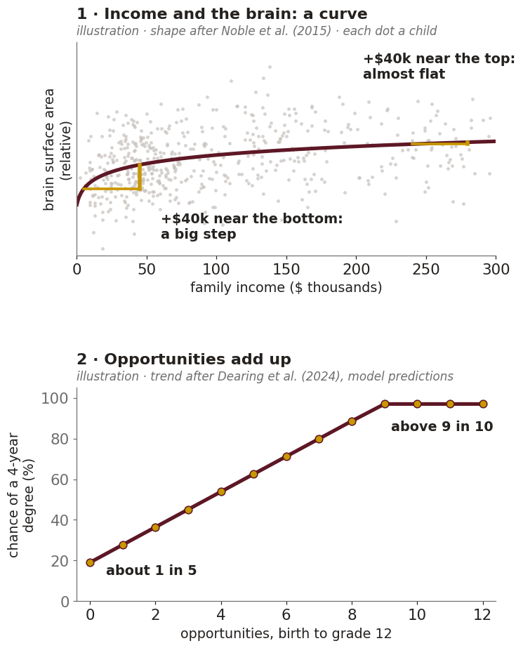

Two curves. Income matters most at the bottom, and opportunities add up.

**Study 3: the school’s SES counts too.** Mahmut Sami Yigiter (2025) pooled 20 years of TIMSS, the international math and science test, from 54 countries and separated two things: a student’s own family SES, and the average SES of the students in the same school. Both predicted achievement, and overall the school’s SES predicted it more strongly, in math and in science. In the U.S., the school effect was about twice the family effect. School SES includes what the whole building has, such as classmates, teachers, funding and expectations. The size of both effects differed mostly from country to country, and in Finland, Norway and Slovenia a student’s own family counts for more than the school. What might those countries do differently with their schools? The study also found that raising a migrant student’s family SES, or the SES of the school they attend, narrowed their achievement gap.

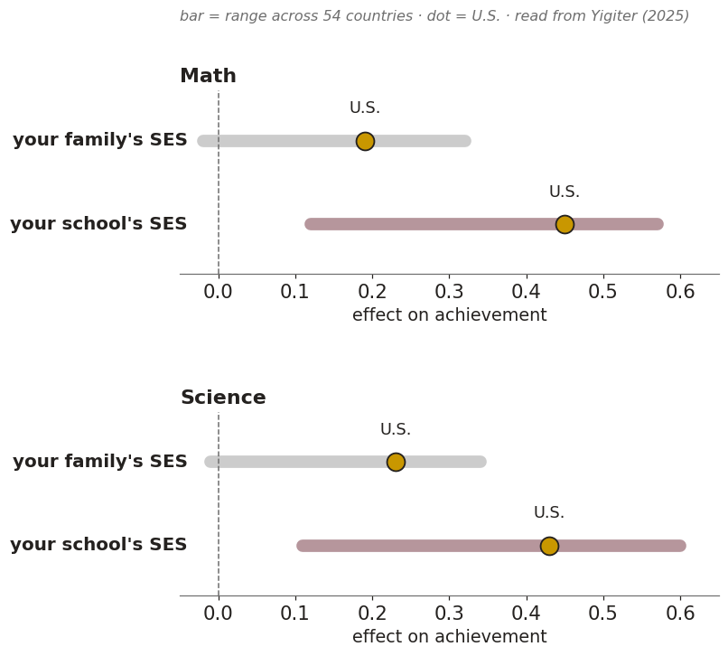

Two kinds of SES. The school a child attends can count more than the child’s own family.

Dearing’s last finding shows what a teacher can do. You cannot change a family’s income, but a classroom, a program, a club, and a teacher who asks again are opportunities, and they count most for the students who have the fewest. Income and opportunity are also different things, because a family can have little of one and much of the other.

Your district file shows another kind of capital. Tanya’s parents are teachers, and her grade 3 referral is two pages long and names the subtests she should get. Knowing what to ask for is capital too.

Read the FRL column with care. Free and reduced lunch counts one thing, which is household income in this country, this year. It does not count the parents’ schooling, their profession, or what they built somewhere else, so a family can qualify honestly and still have a great deal of educational capital. A teacher who reads “FRL, ELL” as “poor, uneducated, behind” has inferred three things that the file never said.

True or false?

A gap in average test scores between high- and low-income students shows a gap in ability between the two groups.

Not quite The gap follows unequal opportunity: books, programs, experienced teachers, time. Dearing et al. (2024) counted those opportunities, and the count predicted degrees and pay. Chapter 4 reads achievement gaps as opportunity gaps.

Right A test measures what a student has learned so far, and learning depends on opportunity. Unequal resources produce unequal scores.

## Learners with exceptionalities

A student is **exceptional** when the regular program does not meet their needs, because of a disability, a gift or talent, or both. In 2022–23, about 7.5 million U.S. students, or 15% of public school students, received services under federal disability law. The largest group, 32% of them, had a specific learning disability (National Center for Education Statistics [NCES], 2024).

IDEA The Individuals with Disabilities Education Act (IDEA) guarantees every student with a qualifying disability a free appropriate public education in the **least restrictive environment**, which means as close to the regular classroom as their needs allow. Each student served gets an **Individualized Education Program (IEP)** with goals, services and accommodations, written by a team that includes the parents.

Section 504 A civil rights law that covers students whose disability limits a major life activity but who do not need special education. A **504 plan** lists accommodations, such as extra time or a quiet testing room, and adds no specialized instruction.

Specific learning disability A difficulty in one area of learning, such as reading, writing or math, in a student whose general intelligence is typical or higher. **Dyslexia** is the most common. It is a difficulty in decoding written words that is rooted in processing the sounds of language (Lyon et al., 2003), and it says nothing about how well the student thinks.

ADHD and autism ADHD appears as trouble sustaining attention, impulsivity, or hyperactivity. Autism appears as differences in social communication and repetitive behaviors or focused interests. Both vary widely, and many students with either diagnosis are capable of advanced work.

Intellectual disability Significant limits in both intellectual functioning and adaptive behavior (everyday conceptual, social and practical skills), beginning before age 22 (American Association on Intellectual and Developmental Disabilities [AAIDD], 2021). The AAIDD adds that limitations often coexist with strengths.

**How students get identified.** Most schools now use **response to intervention (RTI)**, which is part of a wider system called MTSS. All students receive good instruction and a universal screening. Students who fall behind get extra help in small groups, and those who still do not respond get more intensive help and possibly a referral for evaluation.

**A test in the wrong language.** IDEA gives the U.S. one of the most thorough systems in the world for finding disabilities, because every child has a legal right to a free evaluation and the school has to look. Many countries promise much less. A test, though, works only for the kind of students it was normed on, and most U.S. tests were normed mostly on children who grew up here speaking English. For a student born abroad, a vocabulary or reading score can measure time in this country more than ability. The testing profession’s own standards call this a fairness problem (American Educational Research Association [AERA] et al., 2014), and IDEA requires evaluation in the child’s native language, with tests that do not discriminate. Schools still miss in both directions, because English learners tend to be under-identified in the early grades and over-identified later (Samson & Lesaux, 2009; Sullivan, 2011).

When a student born abroad earns a low score, treat the score as a question. Three checks answer most of it. Was the test given in a language the student fully commands? Were students like this one in the norm sample? Does the same difficulty show up in the student’s first language?

On paper, need decides who is evaluated, but in your district file a parent’s request decided it twice. The screening tool learned from those records. Ask the case’s fourth question again: what has the tool learned to predict?

Check yourself

Theo has ADHD. He needs extra time on tests and a seat away from the door. He does not need specialized instruction. Which plan fits?

Not every one An IEP comes with special education services. Theo needs accommodations only.

Risky Without a plan, his accommodations depend on which teacher he gets. A 504 plan makes them his right.

Yes A 504 plan provides accommodations without specialized instruction, which is what Theo needs.

The opposite The least restrictive environment for Theo is the regular classroom with two accommodations.

## The misconception: “dumb it down”

When you ask new teachers what to do for a student with a disability, most say some version of *make it easier*. They suggest shorter readings, fewer questions, or a video in place of the chapter. Their intention is kind.

This is the most common mistake in the chapter, and the law has a name for the difference it ignores. An **accommodation** changes *how* a student gets to the learning or shows it, whereas a **modification** changes *what* the student is expected to learn. Accommodations keep the bar where it is, and modifications lower it. Some students with significant disabilities need modifications, but most students with learning disabilities need accommodations.

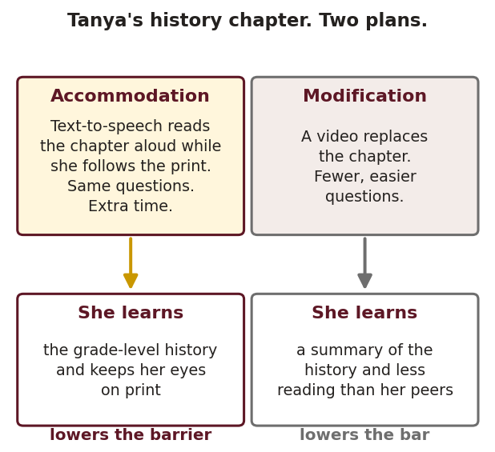

Two plans for Tanya. One lowers the barrier, and the other lowers the bar.

**Consider Tanya.** She has dyslexia and real talent in math, and her history class assigns a chapter a week. Compare two plans:

- **Plan A.** Give her a video instead of the chapter. The plan feels kind, but she gets a summary and reads less every week than her classmates, so over a year the gap in reading grows.
- **Plan B.** Pair **text-to-speech** with the reading. The tool reads the chapter aloud while Tanya follows the words on the page, and she gets the same chapter, the same questions and extra time.

Evidence supports Plan B. A meta-analysis of 22 studies found that text-to-speech improves reading comprehension for students with reading disabilities, with a small-to-moderate effect, *d* = 0.35 (Wood et al., 2018). Because her eyes stay on print, she also keeps practicing.

The accommodation is half the plan. Tanya also needs an **intervention**, which is direct, systematic teaching of how letters map to sounds, in a separate block, from a trained specialist (National Reading Panel, 2000). The accommodation gives her the history today, and the intervention builds her decoding for tomorrow. Her math talent requires a third piece, which is work at her level, even when that level is well ahead of grade.

**Why the bar matters for motivation.** You learned in Weeks 11 and 12 that self-efficacy grows from mastery experiences and that a success on an easy task teaches nothing about your ability. A student who receives an easier task also reads the message: *my teacher doesn’t expect much from me.* You saw the same problem with Mr. Hale in Week 12. Lowering the bar costs the student challenge, opportunity and belief, all at once.

Commit first

Ms. Grant teaches 8th-grade science. Her new student, Eli, has dyslexia. Her plan for him: readings rewritten at a 4th-grade level, no written lab reports, and videos for every chapter. She says, *“I don’t want him to feel overwhelmed.”*

**What does each part of her plan cost Eli? Rewrite one part so it lowers the barrier and keeps the bar.** Two or three sentences.

**All three parts lower the bar.** The 4th-grade readings cut the science vocabulary he needs. Dropping lab reports removes the practice of writing up evidence, which every scientist does, and videos in place of chapters stop his reading practice altogether. Although Eli will feel less overwhelmed this month, he will fall further behind every month after.

**One rewrite:** He reads grade-level texts with text-to-speech, so he hears the words while he reads them. Another option keeps the lab report and lets him dictate it with speech-to-text and then edit it. The science and the report stay the same, and he has a new way to reach them. Ask also whether Eli is getting decoding intervention somewhere in his week.

## Universal Design for Learning

Accommodations adapt the lesson for one student after it is planned. **Universal Design for Learning (UDL)** builds options in from the start, for everyone (CAST, 2024). The idea comes from architecture, where a ramp built for wheelchair users also helps parents with strollers and workers with carts. In the same way, captions written for deaf viewers help everyone in a loud room.

UDL has three principles:

Engagement Offer more than one way to become involved, such as choice of topic, relevance to students’ lives, a manageable level of challenge, and feedback that helps students persist.

Representation Offer the content in more than one way, such as text with audio, a diagram with a description, or a key word with its meaning. Every student gets the same content.

Action and expression Offer more than one way to show learning, such as writing, speaking, building, drawing or recording. The goal stays fixed, and the route is flexible.

**UDL is not learning styles.** Teachers who use learning styles sort students into types and match the format to the type. With UDL, everyone has the options and students use what removes their barrier today. The UDL motto is firm goals, flexible means.

True or false?

Under UDL, a teacher first diagnoses each student’s learning style, then gives each student the format that matches it.

Not quite That is the learning-styles claim, which fails when tested. UDL offers options to everyone and keeps the goal the same for all.

Right UDL plans for the whole range of students at once. It needs no diagnosis and no sorting, because the options are built in and the goal is the same.

## AI that restores capability

Some of the most important AI tools in your students’ lives were built for people with disabilities. Each tool below lowers a barrier, and none of them lowers the bar.

- **Seeing for blind users.** Be My Eyes added *Be My AI* in 2023. A blind user takes a photo, and the app describes it aloud and answers follow-up questions (Be My Eyes, 2023).
- **Speaking again.** A man with ALS who could no longer speak clearly received a brain implant. The system turned his attempted speech into words with about 97% accuracy, in a voice built from old recordings of his own (Card et al., 2024).
- **Keeping your own voice.** Apple’s *Personal Voice*, released in 2023, lets a person at risk of losing speech record about 15 minutes of their voice. The phone then speaks typed text in that voice (Apple, 2023).
- **Sign language to text.** Google announced *SignGemma* in 2025, an AI model that translates American Sign Language into English text (Google DeepMind, 2025).
- **Reading and writing.** Text-to-speech, speech-to-text and live captions are built into every phone and laptop your students carry.

For a teacher, the difficulty is that **the same tool can restore access or offload the learning.** Text-to-speech on a history chapter gives Tanya the history, but text-to-speech on a decoding lesson removes the practice the lesson exists for. In the same way, speech-to-text on a lab report gives Eli the science, but on a spelling test it skips the spelling.

Ask one question every time: **is the tool doing the thing this lesson is for?** If it is, the student offloads the learning. If the tool removes a barrier around the learning, it is an accommodation, and often augmentation.

Check yourself

Owen is blind. Which use of AI offloads what the lesson is for?

Access The lesson is about persuasion. Hearing the article removes a barrier, and Owen still does the persuading.

Access The lesson is the history. The description gives him what sighted classmates see.

Access Dictation changes the route. He still builds the argument and revises it.

## Twice-exceptional learners

A **twice-exceptional (2e)** student has a gift or talent and a disability at the same time. Reis et al. (2014) define 2e students as those whose high ability and disability both need attention, together, in the same plan.

Identification is difficult because of **masking**. The strength hides the disability, the disability hides the strength, or each hides the other.

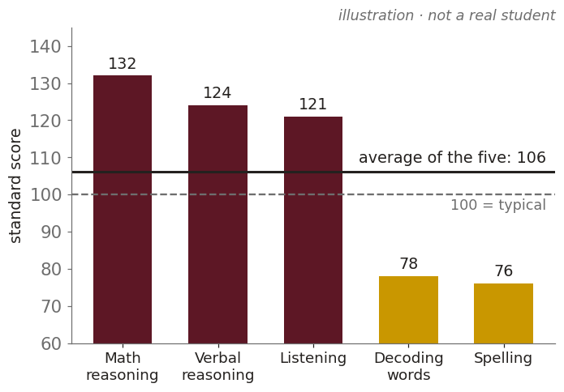

Masking. A strong profile and a disability can average out to “typical.”

In the chart, a student who reasons at 132 and decodes at 78 has an average of 106, and on a single total score she looks typical. She receives no gifted referral because the score is not high enough, and no disability referral because it is not low enough. Her teachers see a bright student who “doesn’t try” on reading.

There are three common patterns (Baum et al., 2017):

1. **The gift shows, the disability hides.** A bright student compensates for years until the reading load becomes greater than the strategies can manage, often in middle school.
2. **The disability shows, the gift hides.** The student is served for the disability only, and nobody offers the advanced work.
3. **Each hides the other.** The student looks average and is served for neither.

**What 2e students need is both, at the same time.** Strength-based plans start with the talent and provide advanced work in the strong domain, plus accommodations and intervention for the disability. A plan that “fixes the reading first, then we’ll see about math” often loses the student’s motivation before the math ever comes. Tanya’s plan works only because it serves both.

In our paper, Desmet and I warn about AI in these cases (Parra-Martinez & Desmet, 2026). A system that receives a disability label and quietly lowers expectations along every dimension at once repeats, at scale, the mistake that 2e research has documented for two decades.

Check yourself

Nia’s IEP is for a writing disability. In class discussion she makes connections nobody else in the room makes. Her written work is short and messy. What fits best?

Fix-first Waiting for the weakness to close before serving the strength is the pattern that loses 2e students. Serve both now.

Yes This plan serves the strength and the disability at the same time. Advanced discussion work feeds the talent, and speech-to-text or a scribe lets her show what she knows.

Masking A strength in one area doesn’t cancel a disability in another. That is exactly how 2e students get missed.

Lowers the bar Easy tasks do not build self-efficacy, and they tell her what you expect of her.

Commit first

Go back to the district file. Michael B. was never evaluated, although the screening tool flagged him for a *sustained grade decline*. You have read about him all term: he tried hard early, failed a major assignment, and now says, *“Why bother? I’m not good at this subject.”*

**Name two things you would want to know about Michael before anyone writes a plan for him. For each, say why it matters.** Two or three sentences.

**There is no single right answer yet.** Good questions examine what the record leaves out:

- **What kind of work does he fail, and what kind does he manage?** He may fail reading-heavy work or all work, and a pattern across task types tells you more than a grade.
- **Was he ever screened for reading, and who would have asked?** The file shows evaluations happen when someone knows to ask.
- **What is he good at?** An asset-based plan starts there.

Keep your two questions. We will come back to Michael.

## Bring it to class

Four questions close the case. *In person:* bring your answers Tuesday, and bring the file; we add to it. *Online:* think them through this week, and use them in Discussion 1.

1. Who in this class has been evaluated, and who asked for it?
2. What had to go right for Tanya’s evaluation, and did each of those things happen for Matthew?
3. Is Tanya the only student the 2e description could fit?
4. If the referral process depended on parents knowing what to ask for, what has the screening tool learned to predict?

**Lower the barrier. Keep the bar.** Then look again, because the student who needs you most may be the one nobody asked about.

## Sources

American Association on Intellectual and Developmental Disabilities. (2021). *Intellectual disability: Definition, diagnosis, classification, and systems of supports* (12th ed.).

American Educational Research Association, American Psychological Association, & National Council on Measurement in Education. (2014). *Standards for educational and psychological testing.* American Educational Research Association.

Apple. (2023, May 16). *Apple introduces new features for cognitive accessibility, along with Live Speech, Personal Voice, and Point and Speak in Magnifier* [Press release]. https://www.apple.com/newsroom/2023/05/apple-previews-live-speech-personal-voice-and-more-new-accessibility-features/

Bastani, H., Bastani, O., Sungu, A., Ge, H., Kabakcı, Ö., & Mariman, R. (2025). Generative AI without guardrails can harm learning: Evidence from high school mathematics. *Proceedings of the National Academy of Sciences, 122*(26), e2422633122. https://doi.org/10.1073/pnas.2422633122

Baum, S. M., Schader, R. M., & Owen, S. V. (2017). *To be gifted and learning disabled: Strength-based strategies for helping twice-exceptional students with LD, ADHD, ASD, and more* (3rd ed.). Prufrock Press.

Be My Eyes. (2023). *Announcing “Be My AI,” soon available for hundreds of thousands of Be My Eyes users*. https://www.bemyeyes.com/blog/announcing-be-my-ai

Bratsberg, B., & Rogeberg, O. (2018). Flynn effect and its reversal are both environmentally caused. *Proceedings of the National Academy of Sciences, 115*(26), 6674–6678. https://doi.org/10.1073/pnas.1718793115

Card, N. S., Wairagkar, M., Iacobacci, C., Hou, X., Singer-Clark, T., Willett, F. R., Kunz, E. M., Fan, C., Vahdati Nia, M., Deo, D. R., Srinivasan, A., Choi, E. Y., Glasser, M. F., Hochberg, L. R., Henderson, J. M., Shahlaie, K., Stavisky, S. D., & Brandman, D. M. (2024). An accurate and rapidly calibrating speech neuroprosthesis. *New England Journal of Medicine, 391*(7), 609–618. https://doi.org/10.1056/NEJMoa2314132

CAST. (2024). *Universal Design for Learning guidelines* (Version 3.0). https://udlguidelines.cast.org

Dearing, E., Bustamante, A. S., Zachrisson, H. D., & Vandell, D. L. (2024). Accumulation of opportunities predicts the educational attainment and adulthood earnings of children born into low- versus higher-income households. *Educational Researcher, 53*(9), 496–507. https://doi.org/10.3102/0013189X241283456

Deary, I. J., Strand, S., Smith, P., & Fernandes, C. (2007). Intelligence and educational achievement. *Intelligence, 35*(1), 13–21.

Dworak, E. M., Revelle, W., & Condon, D. M. (2023). Looking for Flynn effects in a recent online U.S. adult sample: Examining shifts within the SAPA Project. *Intelligence, 98*, 101734. https://doi.org/10.1016/j.intell.2023.101734

Eggen, P. D., & Kauchak, D. P. (2025). *Using educational psychology in teaching* (12th ed.). Pearson. **This week: Chapters 4 and 5.**

Flynn, J. R. (1987). Massive IQ gains in 14 nations: What IQ tests really measure. *Psychological Bulletin, 101*(2), 171–191.

Gardner, H. (1983). *Frames of mind: The theory of multiple intelligences.* Basic Books.

Google DeepMind. (2025). *SignGemma* [Announcement, Google I/O 2025].

Individuals with Disabilities Education Act, 20 U.S.C. § 1400 (2004).

Lyon, G. R., Shaywitz, S. E., & Shaywitz, B. A. (2003). A definition of dyslexia. *Annals of Dyslexia, 53*, 1–14.

McGrew, K. S. (2009). CHC theory and the human cognitive abilities project: Standing on the shoulders of the giants of psychometric intelligence research. *Intelligence, 37*(1), 1–10.

National Center for Education Statistics. (2024). *Students with disabilities.* Condition of Education. U.S. Department of Education. https://nces.ed.gov/programs/coe/indicator/cgg

National Reading Panel. (2000). *Teaching children to read: An evidence-based assessment of the scientific research literature on reading and its implications for reading instruction.* National Institute of Child Health and Human Development.

Noble, K. G., Houston, S. M., Brito, N. H., Bartsch, H., Kan, E., Kuperman, J. M., Akshoomoff, N., Amaral, D. G., Bloss, C. S., Libiger, O., Schork, N. J., Murray, S. S., Casey, B. J., Chang, L., Ernst, T. M., Frazier, J. A., Gruen, J. R., Kennedy, D. N., Van Zijl, P., . . . Sowell, E. R. (2015). Family income, parental education and brain structure in children and adolescents. *Nature Neuroscience, 18*(5), 773–778. https://doi.org/10.1038/nn.3983

Parra-Martinez, F. A., & Desmet, O. A. (2026). Offload, surrender, or augment? Designing continuous talent development in the age of AI. *Gifted Education International.* Advance online publication.

Parra-Martinez, F. A., & Wai, J. (2023). Talent identification research: A bibliometric study from multidisciplinary and global perspectives. *Frontiers in Psychology, 14*, 1141159. https://doi.org/10.3389/fpsyg.2023.1141159

Pashler, H., McDaniel, M., Rohrer, D., & Bjork, R. (2008). Learning styles: Concepts and evidence. *Psychological Science in the Public Interest, 9*(3), 105–119.

Reis, S. M., Baum, S. M., & Burke, E. (2014). An operational definition of twice-exceptional learners: Implications and applications. *Gifted Child Quarterly, 58*(3), 217–230. https://doi.org/10.1177/0016986214534976

Rehabilitation Act of 1973, Section 504, 29 U.S.C. § 794.

Risko, E. F., & Gilbert, S. J. (2016). Cognitive offloading. *Trends in Cognitive Sciences, 20*(9), 676–688. https://doi.org/10.1016/j.tics.2016.07.002

Ritchie, S. J., & Tucker-Drob, E. M. (2018). How much does education improve intelligence? A meta-analysis. *Psychological Science, 29*(8), 1358–1369.

Samson, J. F., & Lesaux, N. K. (2009). Language-minority learners in special education: Rates and predictors of identification for services. *Journal of Learning Disabilities, 42*(2), 148–162.

Shaw, S. D., & Nave, G. (2026). *Thinking—fast, slow, and artificial: How AI is reshaping human reasoning and the rise of cognitive surrender* [Preprint]. OSF Preprints. https://osf.io/preprints/psyarxiv/yk25n_v1

Sirin, S. R. (2005). Socioeconomic status and academic achievement: A meta-analytic review of research. *Review of Educational Research, 75*(3), 417–453. https://doi.org/10.3102/00346543075003417

Spearman, C. (1904). “General intelligence,” objectively determined and measured. *American Journal of Psychology, 15*(2), 201–292.

Sternberg, R. J. (1985). *Beyond IQ: A triarchic theory of human intelligence.* Cambridge University Press.

Sternberg, R. J. (2021). *Adaptive intelligence: Surviving and thriving in times of uncertainty.* Cambridge University Press.

Subotnik, R. F., Olszewski-Kubilius, P., & Worrell, F. C. (2011). Rethinking giftedness and gifted education: A proposed direction forward based on psychological science. *Psychological Science in the Public Interest, 12*(1), 3–54.

Sullivan, A. L. (2011). Disproportionality in special education identification and placement of English language learners. *Exceptional Children, 77*(3), 317–334.

Wood, S. G., Moxley, J. H., Tighe, E. L., & Wagner, R. K. (2018). Does use of text-to-speech and related read-aloud tools improve reading comprehension for students with reading disabilities? A meta-analysis. *Journal of Learning Disabilities, 51*(1), 73–84. https://doi.org/10.1177/0022219416688170

Yigiter, M. S. (2025). The effect of socioeconomic status on academic achievement: A big data study across countries and time with integrative data analysis. *PLOS ONE, 20*(10), Article e0335485. https://doi.org/10.1371/journal.pone.0335485

Ziegler, A., & Baker, J. (2013). Talent development as adaptation: The role of educational and learning capital. In S. N. Phillipson, H. Stoeger, & A. Ziegler (Eds.), *Exceptionality in East Asia: Explorations in the actiotope model of giftedness* (pp. 18–39). Routledge.